# Subset selection - Practice H/W

Hillary

1/29/2020

#### 1. Load the cpus dataset from the MASS package

```r
library(MASS)
library(tidyverse)
library(caret)
library(leaps)
# inspect data
sample_n(cpus,5)
```

```
##              name syct mmin mmax cach chmin chmax perf estperf
## 1      HARRIS 100  300  768 3000    0     6    24   36      23
## 2 BURROUGHS B2925  143 1000 2000    0     5    16   31      22
## 3       NCR V8650   38 4000 8000   32    16    32  116      80
## 4    NCR V8545 II   84 1000 2000    0     1     6   12      21
## 5      IBM 8130 B 1500  768 2000    0     0     0   18      20
```

#### 2. Use syct, mmin , mmax , cach , chmin, chmax as the predictors (independent variables) to predict performance (perf)

```r
models <- regsubsets(perf~syct + mmin + mmax + cach + chmin + chmax, data = cpus, nvmax = 6)
summary(models)
```

```
## Subset selection object
## Call: regsubsets.formula(perf ~ syct + mmin + mmax + cach + chmin +
##     chmax, data = cpus, nvmax = 6)
## 6 Variables  (and intercept)
##       Forced in Forced out
## syct      FALSE      FALSE
## mmin      FALSE      FALSE
## mmax      FALSE      FALSE
## cach      FALSE      FALSE
## chmin     FALSE      FALSE
## chmax     FALSE      FALSE
## 1 subsets of each size up to 6
## Selection Algorithm: exhaustive
##          syct mmin mmax cach chmin chmax
## 1  ( 1 ) " "  " "  "*"  " "  " "   " "
## 2  ( 1 ) " "  " "  "*"  "*"  " "   " "
## 3  ( 1 ) " "  "*"  "*"  " "  " "   "*"
## 4  ( 1 ) " "  "*"  "*"  "*"  " "   "*"
## 5  ( 1 ) "*"  "*"  "*"  "*"  " "   "*"
## 6  ( 1 ) "*"  "*"  "*"  "*"  "*"   "*"
```

#### 3. Perform best subset selection in order to choose the best predictors from the above predictors. What is the best model obtained according to Cp, BIC, and adjusted R2?

Model selection criteria: Adjusted R2, Cp and BIC

```r
res.sum <- summary(models)
res.sum$cp
```

```
## [1] 176.563616  95.808585  28.225948  10.977588   5.099604   7.000000
```

```r
res.sum$bic
```

```
## [1] -274.7146 -320.4675 -370.5300 -383.5185 -386.1684 -380.9290
```

```r
data.frame(
  Adj.R2 = which.max(res.sum$adjr2),
  CP = which.min(res.sum$cp),
  BIC = which.min(res.sum$bic)
)
```

```
##   Adj.R2 CP BIC
## 1      5  5   5
```

As shown above, adjusted R2,BIC and Cp criteria, tells us that the best model is the one with all the 5 predictor variables.

#### 4.Show some plots to provide evidence for your answer, and report the coefficients of the best model obtained for each criteria

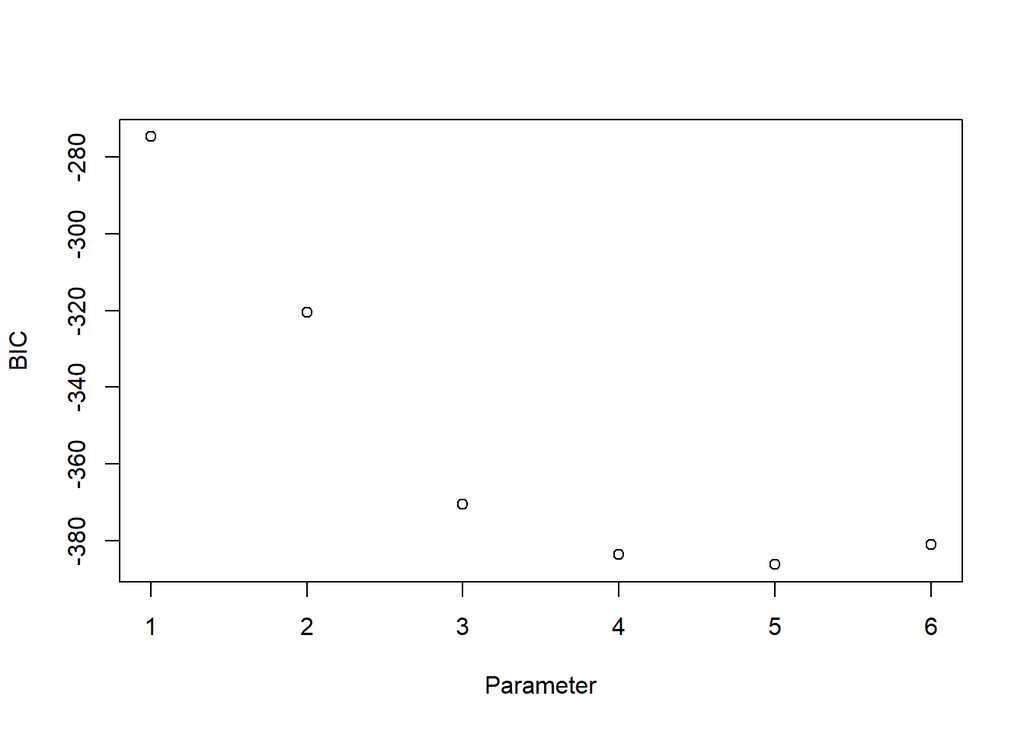

```r
plot(res.sum$bic, xlab="Parameter", ylab="BIC")
```

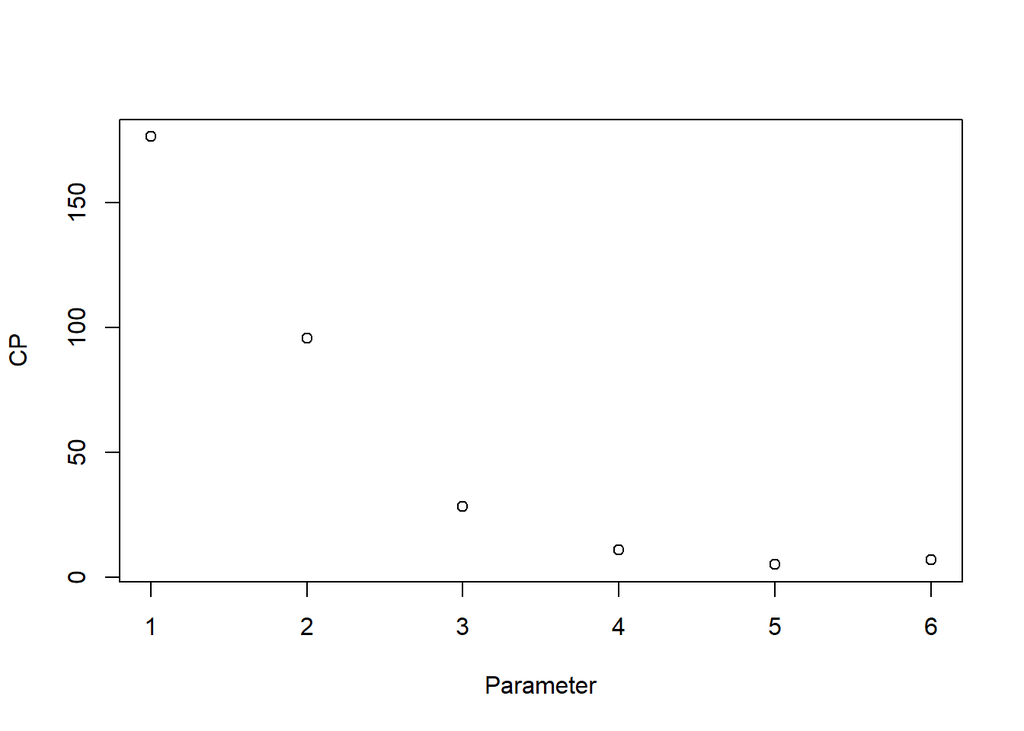

```r
plot(res.sum$cp, xlab="Parameter", ylab="CP")
```

#### 5. Repeat using forward stepwise selection and also using backwards stepwise selection.How does your answer compare to the best subset results?

Fit the full model

```r
library(MASS)
full.model <- lm(perf ~syct + mmin + mmax + cach + chmin + chmax, data = cpus)
full.model
```

```
##
## Call:
## lm(formula = perf ~ syct + mmin + mmax + cach + chmin + chmax,
##     data = cpus)
##
## Coefficients:
## (Intercept)         syct         mmin         mmax         cach        chmin
##  -55.900116     0.048863     0.015294     0.005571     0.641207    -0.270065
##       chmax
##    1.482694
```

Stepwise regression model

```r
step.model <- stepAIC(full.model, direction = "both",trace = FALSE)
summary(step.model)
```

```
##
## Call:
## lm(formula = perf ~ syct + mmin + mmax + cach + chmax, data = cpus)
##
## Residuals:
##     Min      1Q  Median      3Q     Max
## -193.39  -24.94    5.77   26.65  389.66
##
## Coefficients:
##               Estimate Std. Error t value Pr(>|t|)
## (Intercept) -5.608e+01  8.007e+00  -7.004 3.58e-11 ***
## syct         4.912e-02  1.746e-02   2.813  0.00539 **
## mmin         1.518e-02  1.788e-03   8.490 4.34e-15 ***
## mmax         5.561e-03  6.397e-04   8.694 1.18e-15 ***
## cach         6.296e-01  1.344e-01   4.686 5.11e-06 ***
## chmax        1.460e+00  2.076e-01   7.032 3.05e-11 ***
## ---
## Signif. codes:  0 '***' 0.001 '**' 0.01 '*' 0.05 '.' 0.1 ' ' 1
##
## Residual standard error: 59.86 on 203 degrees of freedom
## Multiple R-squared:  0.8648, Adjusted R-squared:  0.8615
## F-statistic: 259.7 on 5 and 203 DF,  p-value: < 2.2e-16
```

```r
models <- regsubsets(perf ~syct + mmin + mmax + cach + chmin + chmax, data = cpus,
                     nvmax = 6,
                     method = "seqrep")
summary(models)
```

```
## Subset selection object
## Call: regsubsets.formula(perf ~ syct + mmin + mmax + cach + chmin +
##     chmax, data = cpus, nvmax = 6, method = "seqrep")
## 6 Variables  (and intercept)
##       Forced in Forced out
## syct      FALSE      FALSE
## mmin      FALSE      FALSE
## mmax      FALSE      FALSE
## cach      FALSE      FALSE
## chmin     FALSE      FALSE
## chmax     FALSE      FALSE
## 1 subsets of each size up to 6
## Selection Algorithm: 'sequential replacement'
##          syct mmin mmax cach chmin chmax
## 1  ( 1 ) " "  " "  "*"  " "  " "   " "
## 2  ( 1 ) " "  " "  "*"  "*"  " "   " "
## 3  ( 1 ) " "  "*"  "*"  " "  " "   "*"
## 4  ( 1 ) "*"  "*"  "*"  "*"  " "   " "
## 5  ( 1 ) "*"  "*"  "*"  "*"  "*"   " "
## 6  ( 1 ) "*"  "*"  "*"  "*"  "*"   "*"
```

Backward elimination

```r
# Set seed for reproducibility
set.seed(123)
# Set up repeated k-fold cross-validation
train.control <- trainControl(method = "cv", number = 6)
# Train the model
step.model <- train(perf ~syct + mmin + mmax + cach + chmin + chmax, data = cpus,
                    method = "leapBackward",
                    tuneGrid = data.frame(nvmax = 1:5),
                    trControl = train.control)
step.model$results
```

```
##   nvmax     RMSE  Rsquared      MAE   RMSESD RsquaredSD     MAESD
## 1     1 87.75049 0.6761010 52.18444 29.86796 0.18565146 12.546084
## 2     2 79.45335 0.7654028 47.09181 31.08018 0.04330317 12.291333
## 3     3 68.97489 0.8361906 43.31553 30.75232 0.06737224 13.596835
## 4     4 64.32948 0.8688304 41.29585 24.27330 0.03781525 10.353315
## 5     5 63.32082 0.8720109 40.42851 23.68761 0.03659710  9.562039
```